# Super Store Order Forecastings

```python
import warnings
import itertools
import numpy as np
import matplotlib.pyplot as plt
warnings.filterwarnings("ignore")
plt.style.use('fivethirtyeight')
import pandas as pd
import statsmodels.api as sm
import matplotlib

matplotlib.rcParams['axes.labelsize'] = 14
matplotlib.rcParams['xtick.labelsize'] = 12
matplotlib.rcParams['ytick.labelsize'] = 12
matplotlib.rcParams['text.color'] = 'k'
```

We are going to do time series analysis and forecasting for furniture sales.

```python
df = pd.read_excel("Superstore.xls")
furniture = df.loc[df['Category'] == 'Furniture']
```

We have a good 4-year furniture sales data.

```python
furniture['Order Date'].min()
```

```
Timestamp('2014-01-06 00:00:00')
```

```python
furniture['Order Date'].max()
```

```
Timestamp('2017-12-30 00:00:00')
```

## Data preprocessing

This step includes removing columns we do not need, check missing values, aggregate sales by date and so on.

```python
cols = ['Row ID', 'Order ID', 'Ship Date', 'Ship Mode', 'Customer ID', 'Customer Name', 'Segment', 'Country', 'City', 'State', 'Postal Code', 'Region', 'Product ID', 'Category', 'Sub-Category', 'Product Name', 'Quantity', 'Discount', 'Profit']
furniture.drop(cols, axis=1, inplace=True)
furniture = furniture.sort_values('Order Date')
```

```python
furniture.isnull().sum()
```

```
Order Date    0
Sales         0
dtype: int64
```

```python
furniture = furniture.groupby('Order Date')['Sales'].sum().reset_index()
```

```python
furniture.head()
```

|  | Order Date | Sales |
| --- | --- | --- |
| 0 | 2014-01-06 | 2573.820 |
| 1 | 2014-01-07 | 76.728 |
| 2 | 2014-01-10 | 51.940 |
| 3 | 2014-01-11 | 9.940 |
| 4 | 2014-01-13 | 879.939 |

## Indexing with time series data

```python
furniture = furniture.set_index('Order Date')
furniture.index
```

```
DatetimeIndex(['2014-01-06', '2014-01-07', '2014-01-10', '2014-01-11',
               '2014-01-13', '2014-01-14', '2014-01-16', '2014-01-19',
               '2014-01-20', '2014-01-21',
               ...
               '2017-12-18', '2017-12-19', '2017-12-21', '2017-12-22',
               '2017-12-23', '2017-12-24', '2017-12-25', '2017-12-28',
               '2017-12-29', '2017-12-30'],
              dtype='datetime64[ns]', name='Order Date', length=889, freq=None)
```

Our current datetime data can be tricky to work with, therefore, we will use the averages daily sales value for that month instead, and we are using the start of each month as the timestamp.

```python
y = furniture['Sales'].resample('MS').mean()
```

Have a quick peek 2017 sales data.

```python
y['2017':]
```

```
Order Date
2017-01-01     397.602133
2017-02-01     528.179800
2017-03-01     544.672240
2017-04-01     453.297905
2017-05-01     678.302328
2017-06-01     826.460291
2017-07-01     562.524857
2017-08-01     857.881889
2017-09-01    1209.508583
2017-10-01     875.362728
2017-11-01    1277.817759
2017-12-01    1256.298672
Freq: MS, Name: Sales, dtype: float64
```

## Visualizing furniture sales time series data

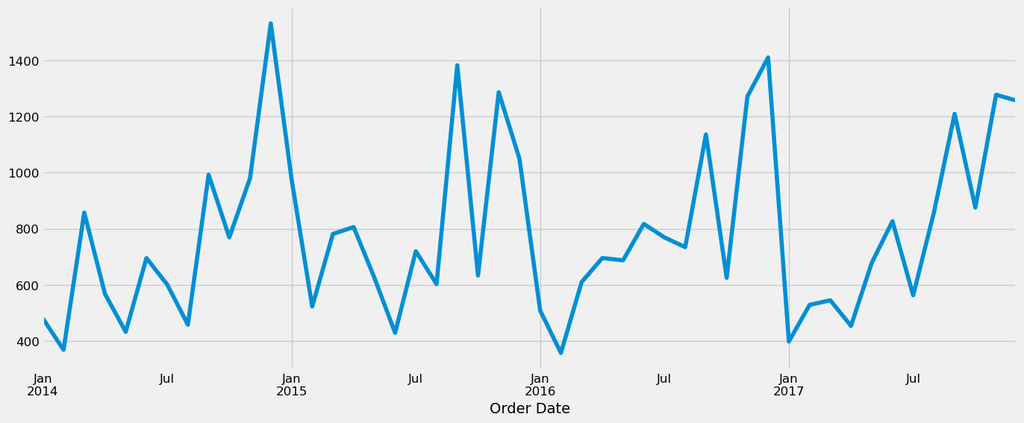

```python
y.plot(figsize=(15, 6))
plt.show()
```

Some distinguishable patterns appear when we plot the data. The time-series has seasonality pattern, such as sales are always low at the beginning of the year and high at the end of the year. There is always a strong upward trend within any single year with a couple of low months in the mid of the year.

We can also visualize our data using a method called time-series decomposition that allows us to decompose our time series into three distinct components: trend, seasonality, and noise.

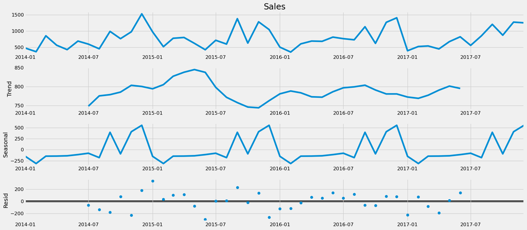

```python
from pylab import rcParams
rcParams['figure.figsize'] = 18, 8

decomposition = sm.tsa.seasonal_decompose(y, model='additive')
fig = decomposition.plot()
plt.show()
```

The plot above clearly shows that the sales of furniture is unstable, along with its obvious seasonality.

## Time series forecasting with ARIMA

We are going to apply one of the most commonly used method for time-series forecasting, known as ARIMA, which stands for Autoregressive Integrated Moving Average.

Parameter Selection for the ARIMA Time Series Model

```python
p = d = q = range(0, 2)
pdq = list(itertools.product(p, d, q))
seasonal_pdq = [(x[0], x[1], x[2], 12) for x in list(itertools.product(p, d, q))]

print('Examples of parameter combinations for Seasonal ARIMA...')
print('SARIMAX: {} x {}'.format(pdq[1], seasonal_pdq[1]))
print('SARIMAX: {} x {}'.format(pdq[1], seasonal_pdq[2]))
print('SARIMAX: {} x {}'.format(pdq[2], seasonal_pdq[3]))
print('SARIMAX: {} x {}'.format(pdq[2], seasonal_pdq[4]))
```

```
Examples of parameter combinations for Seasonal ARIMA...
SARIMAX: (0, 0, 1) x (0, 0, 1, 12)
SARIMAX: (0, 0, 1) x (0, 1, 0, 12)
SARIMAX: (0, 1, 0) x (0, 1, 1, 12)
SARIMAX: (0, 1, 0) x (1, 0, 0, 12)
```

```python
for param in pdq:
    for param_seasonal in seasonal_pdq:
        try:
            mod = sm.tsa.statespace.SARIMAX(y,
                                            order=param,
                                            seasonal_order=param_seasonal,
                                            enforce_invertibility=False)

            results = mod.fit()

            print('ARIMA{}x{}12 - AIC:{}'.format(param, param_seasonal, results.aic))
        except:
            continue
```

[output not shown]

[output cut: 119 more lines]

[output not shown]

[output not shown]

[output not shown]

[output cut: 89 more lines]

[output not shown]

[output not shown]

[output not shown]

[output cut: 96 more lines]

[output not shown]

[output not shown]

[output not shown]

[output cut: 129 more lines]

[output not shown]

[output not shown]

[output not shown]

[output cut: 31 more lines]

[output not shown]

[output not shown]

[output cut: 87 more lines]

[output not shown]

[output not shown]

[output cut: 229 more lines]

[output not shown]

[output not shown]

[output cut: 91 more lines]

[output not shown]

[output not shown]

[output not shown]

[output cut: 42 more lines]

[output not shown]

[output not shown]

[output not shown]

[output cut: 40 more lines]

[output not shown]

[output not shown]

[output not shown]

[output cut: 34 more lines]

[output not shown]

[output not shown]

[output cut: 19 more lines]

[output not shown]

[output not shown]

[output not shown]

[output cut: 184 more lines]

[output not shown]

[output not shown]

[output not shown]

[output cut: 29 more lines]

[output not shown]

[output not shown]

[output not shown]

[output cut: 43 more lines]

[output not shown]

[output not shown]

[output not shown]

[output cut: 72 more lines]

[output not shown]

```
 This problem is unconstrained.
```

[output not shown]

[output not shown]

[output not shown]

[output cut: 45 more lines]

[output not shown]

```python
mod = sm.tsa.statespace.SARIMAX(y,
                                order=(1, 1, 1),
                                seasonal_order=(1, 1, 0, 12),
                                enforce_invertibility=False)

results = mod.fit()

print(results.summary().tables[1])
```

[output not shown]

```
 This problem is unconstrained.
```

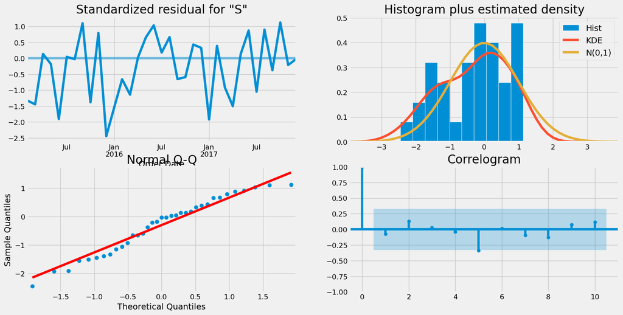

```python
results.plot_diagnostics(figsize=(16, 8))
plt.show()
```

## Validating forecasts

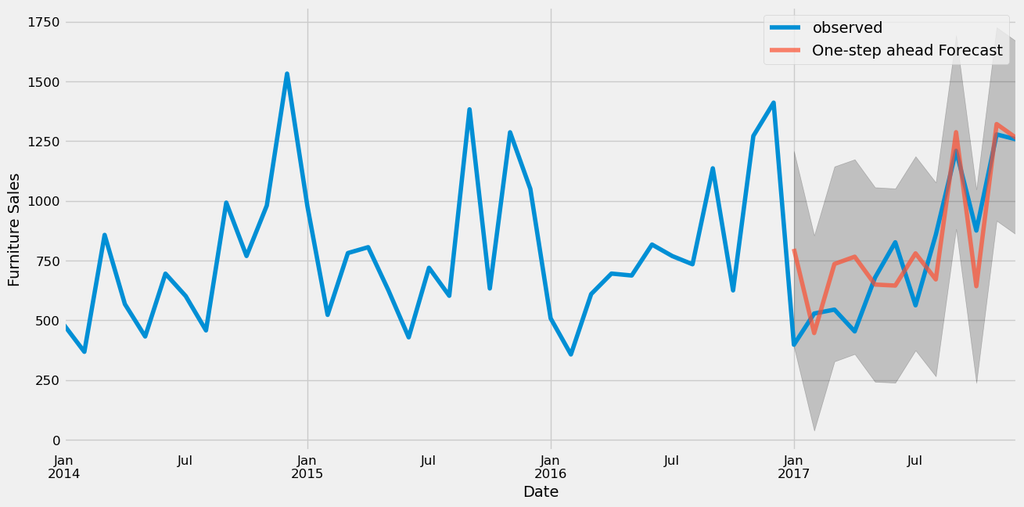

```python
pred = results.get_prediction(start=pd.to_datetime('2017-01-01'), dynamic=False)
pred_ci = pred.conf_int()

ax = y['2014':].plot(label='observed')
pred.predicted_mean.plot(ax=ax, label='One-step ahead Forecast', alpha=.7, figsize=(14, 7))

ax.fill_between(pred_ci.index,
                pred_ci.iloc[:, 0],
                pred_ci.iloc[:, 1], color='k', alpha=.2)

ax.set_xlabel('Date')
ax.set_ylabel('Furniture Sales')
plt.legend()

plt.show()
```

The line plot is showing the observed values compared to the rolling forecast predictions. Overall, our forecasts align with the true values very well, showing an upward trend starts from the beginning of the year.

```python
y_forecasted = pred.predicted_mean
y_truth = y['2017-01-01':]

# Compute the mean square error
mse = ((y_forecasted - y_truth) ** 2).mean()
print('The Mean Squared Error of our forecasts is {}'.format(round(mse, 2)))
```

```
The Mean Squared Error of our forecasts is 39996.01
```

```python
print('The Root Mean Squared Error of our forecasts is {}'.format(round(np.sqrt(mse), 2)))
```

```
The Root Mean Squared Error of our forecasts is 199.99
```

In statistics, the mean squared error (MSE) of an estimator measures the average of the squares of the errors — that is, the average squared difference between the estimated values and what is estimated. The MSE is a measure of the quality of an estimator—it is always non-negative, and the smaller the MSE, the closer we are to finding the line of best fit.

## Producing and visualizing forecasts

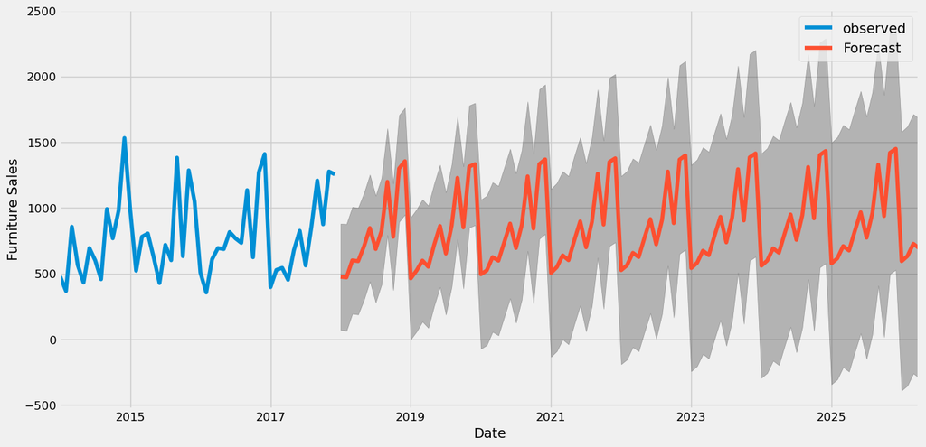

```python
pred_uc = results.get_forecast(steps=100)
pred_ci = pred_uc.conf_int()

ax = y.plot(label='observed', figsize=(14, 7))
pred_uc.predicted_mean.plot(ax=ax, label='Forecast')
ax.fill_between(pred_ci.index,
                pred_ci.iloc[:, 0],
                pred_ci.iloc[:, 1], color='k', alpha=.25)
ax.set_xlabel('Date')
ax.set_ylabel('Furniture Sales')

plt.legend()
plt.show()
```

Our model clearly captured furniture sales seasonality. As we forecast further out into the future, it is natural for us to become less confident in our values. This is reflected by the confidence intervals generated by our model, which grow larger as we move further out into the future.

The above time series analysis for furniture makes me curious about other categories, and how do they compare with each other onver time. Therefore, we are going to compare time series of furniture and office supplier.

## Time Series comparison furniture sales and Office Supplies

### Data Preprocessing

```python
furniture = df.loc[df['Category'] == 'Furniture']
office = df.loc[df['Category'] == 'Office Supplies']
```

According to our data, there were way more number of sales from Office Supplies than from Furniture over the years.

```python
furniture.shape, office.shape
```

```
((2121, 21), (6026, 21))
```

```python
cols = ['Row ID', 'Order ID', 'Ship Date', 'Ship Mode', 'Customer ID', 'Customer Name', 'Segment', 'Country', 'City', 'State', 'Postal Code', 'Region', 'Product ID', 'Category', 'Sub-Category', 'Product Name', 'Quantity', 'Discount', 'Profit']
furniture.drop(cols, axis=1, inplace=True)
office.drop(cols, axis=1, inplace=True)

furniture = furniture.sort_values('Order Date')
office = office.sort_values('Order Date')

furniture = furniture.groupby('Order Date')['Sales'].sum().reset_index()
office = office.groupby('Order Date')['Sales'].sum().reset_index()
```

Have a quick peek, perfect!

```python
furniture.head()
```

|  | Order Date | Sales |
| --- | --- | --- |
| 0 | 2014-01-06 | 2573.820 |
| 1 | 2014-01-07 | 76.728 |
| 2 | 2014-01-10 | 51.940 |
| 3 | 2014-01-11 | 9.940 |
| 4 | 2014-01-13 | 879.939 |

```python
office.head()
```

|  | Order Date | Sales |
| --- | --- | --- |
| 0 | 2014-01-03 | 16.448 |
| 1 | 2014-01-04 | 288.060 |
| 2 | 2014-01-05 | 19.536 |
| 3 | 2014-01-06 | 685.340 |
| 4 | 2014-01-07 | 10.430 |

### Data exploration

We are going to compare two categories' sales in the same time period. This means combine two data frames into one and plot these two categories' time series into one plot.

```python
furniture = furniture.set_index('Order Date')
office = office.set_index('Order Date')

y_furniture = furniture['Sales'].resample('MS').mean()
y_office = office['Sales'].resample('MS').mean()

furniture = pd.DataFrame({'Order Date':y_furniture.index, 'Sales':y_furniture.values})
office = pd.DataFrame({'Order Date': y_office.index, 'Sales': y_office.values})

store = furniture.merge(office, how='inner', on='Order Date')
store.rename(columns={'Sales_x': 'furniture_sales', 'Sales_y': 'office_sales'}, inplace=True)
store.head()
```

|  | Order Date | furniture_sales | office_sales |
| --- | --- | --- | --- |
| 0 | 2014-01-01 | 480.194231 | 285.357647 |
| 1 | 2014-02-01 | 367.931600 | 63.042588 |
| 2 | 2014-03-01 | 857.291529 | 391.176318 |
| 3 | 2014-04-01 | 567.488357 | 464.794750 |
| 4 | 2014-05-01 | 432.049188 | 324.346545 |

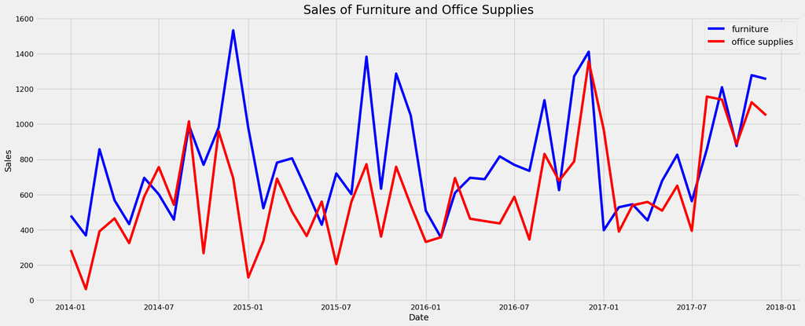

```python
plt.figure(figsize=(20, 8))
plt.plot(store['Order Date'], store['furniture_sales'], 'b-', label = 'furniture')
plt.plot(store['Order Date'], store['office_sales'], 'r-', label = 'office supplies')
plt.xlabel('Date'); plt.ylabel('Sales'); plt.title('Sales of Furniture and Office Supplies')
plt.legend();
```

We observe that sales of furniture and office supplies shared a similar seasonal pattern. Early of the year is the off season for both of the two categories. It seems summer time is quiet for office supplies too. in addition, average daily sales for furniture are higher than those of office supplies in most of the months. It is understandable, as the value of furniture should be much higher than those of office supplies. Occationaly, office supplies passed furnitue on average daily sales. Let's find out when was the first time office supplies' sales surpassed those of furniture's.

```python
first_date = store.loc[np.min(list(np.where(store['office_sales'] > store['furniture_sales'])[0])), 'Order Date']

print("Office supplies first time produced higher sales than furniture is {}.".format(first_date.date()))
```

```
Office supplies first time produced higher sales than furniture is 2014-07-01.
```

It was July 2014.

### Time Series Modeling with Prophet

Released by Facebook in 2017, forecasting tool Prophet is designed for analyzing time-series that display patterns on different time scales such as yearly, weekly and daily. It also has advanced capabilities for modeling the effects of holidays on a time-series and implementing custom changepoints. Therefore, we are using Prophet to get a model up and running.

```python
from prophet import Prophet

furniture = furniture.rename(columns={'Order Date': 'ds', 'Sales': 'y'})
furniture_model = Prophet(interval_width=0.95)
furniture_model.fit(furniture)

office = office.rename(columns={'Order Date': 'ds', 'Sales': 'y'})
office_model = Prophet(interval_width=0.95)
office_model.fit(office)
```

[output not shown]

[output not shown]

[output cut: 50 more lines]

[output not shown]

```
<prophet.forecaster.Prophet at 0x140945100>
```

[output not shown]

```python
furniture_forecast = furniture_model.make_future_dataframe(periods=36, freq='MS')
furniture_forecast = furniture_model.predict(furniture_forecast)

office_forecast = office_model.make_future_dataframe(periods=36, freq='MS')
office_forecast = office_model.predict(office_forecast)
```

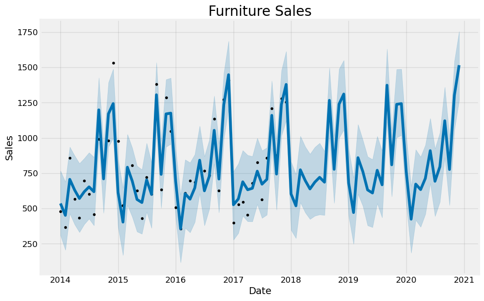

```python
plt.figure(figsize=(18, 6))
furniture_model.plot(furniture_forecast, xlabel = 'Date', ylabel = 'Sales')
plt.title('Furniture Sales');
```

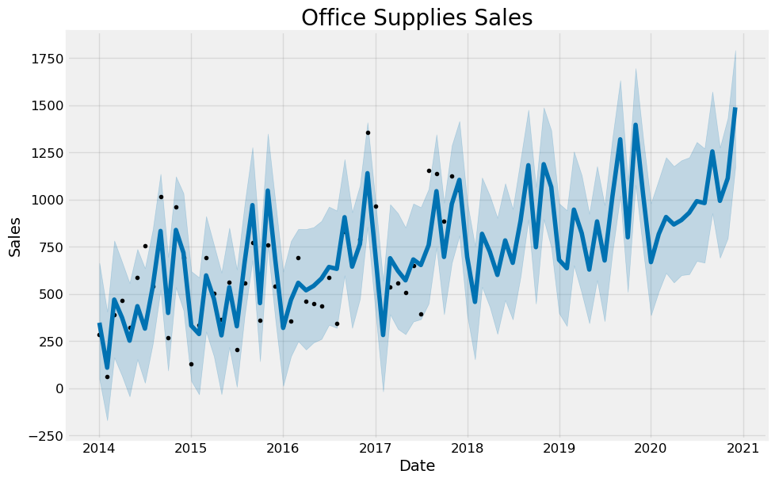

```python
plt.figure(figsize=(18, 6))
office_model.plot(office_forecast, xlabel = 'Date', ylabel = 'Sales')
plt.title('Office Supplies Sales');
```

### Compare Forecasts

We already have the forecasts for three years for these two categories into the future. We will now join them together to compare their future forecasts.

```python
furniture_names = ['furniture_%s' % column for column in furniture_forecast.columns]
office_names = ['office_%s' % column for column in office_forecast.columns]

merge_furniture_forecast = furniture_forecast.copy()
merge_office_forecast = office_forecast.copy()

merge_furniture_forecast.columns = furniture_names
merge_office_forecast.columns = office_names

forecast = pd.merge(merge_furniture_forecast, merge_office_forecast, how = 'inner', left_on = 'furniture_ds', right_on = 'office_ds')

forecast = forecast.rename(columns={'furniture_ds': 'Date'}).drop('office_ds', axis=1)
forecast.head()
```

|  | Date | furniture_trend | furniture_yhat_lower | furniture_yhat_upper | furniture_trend_lower | furniture_trend_upper | furniture_additive_terms | furniture_additive_terms_lower | furniture_additive_terms_upper | furniture_yearly | ... | office_additive_terms | office_additive_terms_lower | office_additive_terms_upper | office_yearly | office_yearly_lower | office_yearly_upper | office_multiplicative_terms | office_multiplicative_terms_lower | office_multiplicative_terms_upper | office_yhat |
| --- | --- | --- | --- | --- | --- | --- | --- | --- | --- | --- | --- | --- | --- | --- | --- | --- | --- | --- | --- | --- | --- |
| 0 | 2014-01-01 | 726.057713 | 308.847618 | 766.893401 | 726.057713 | 726.057713 | -190.685662 | -190.685662 | -190.685662 | -190.685662 | ... | -140.040481 | -140.040481 | -140.040481 | -140.040481 | -140.040481 | -140.040481 | 0.0 | 0.0 | 0.0 | 347.490278 |
| 1 | 2014-02-01 | 727.494023 | 205.973005 | 688.341122 | 727.494023 | 727.494023 | -276.377703 | -276.377703 | -276.377703 | -276.377703 | ... | -385.678283 | -385.678283 | -385.678283 | -385.678283 | -385.678283 | -385.678283 | 0.0 | 0.0 | 0.0 | 109.240162 |
| 2 | 2014-03-01 | 728.791335 | 464.177460 | 936.271600 | 728.791335 | 728.791335 | -22.389755 | -22.389755 | -22.389755 | -22.389755 | ... | -31.379844 | -31.379844 | -31.379844 | -31.379844 | -31.379844 | -31.379844 | 0.0 | 0.0 | 0.0 | 470.211349 |
| 3 | 2014-04-01 | 730.227645 | 386.124561 | 873.643884 | 730.227645 | 730.227645 | -100.141158 | -100.141158 | -100.141158 | -100.141158 | ... | -134.291690 | -134.291690 | -134.291690 | -134.291690 | -134.291690 | -134.291690 | 0.0 | 0.0 | 0.0 | 374.687188 |
| 4 | 2014-05-01 | 731.617622 | 331.461015 | 819.125115 | 731.617622 | 731.617622 | -160.815662 | -160.815662 | -160.815662 | -160.815662 | ... | -263.821569 | -263.821569 | -263.821569 | -263.821569 | -263.821569 | -263.821569 | 0.0 | 0.0 | 0.0 | 252.306682 |

5 rows × 31 columns

### Visualizing the trend and the forecast

```
WARNING:matplotlib.legend:No artists with labels found to put in legend.  Note that artists whose label start with an underscore are ignored when legend() is called with no argument.
```

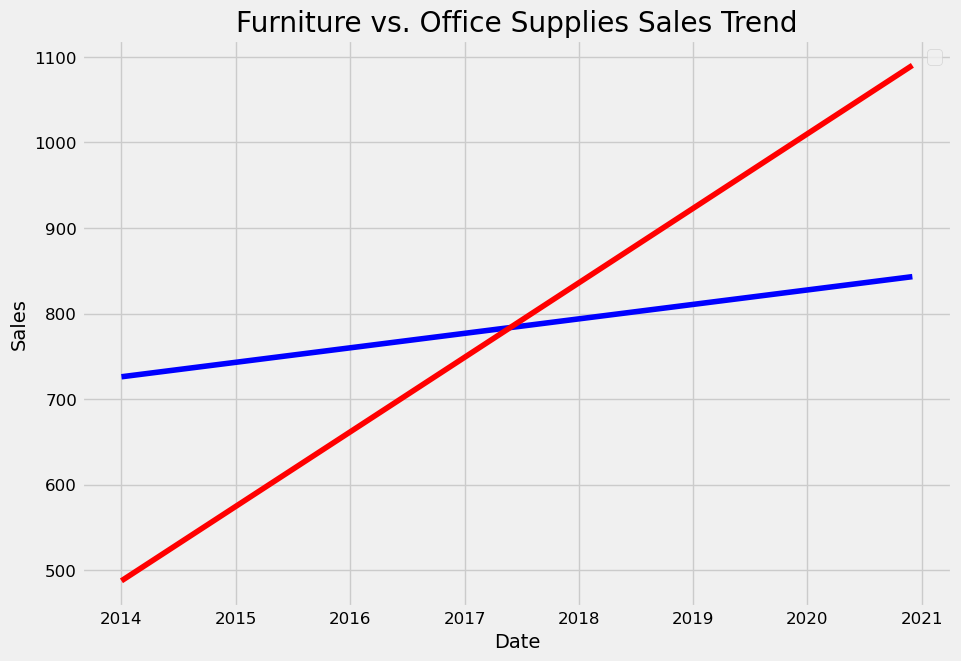

```python
plt.figure(figsize=(10, 7))
plt.plot(forecast['Date'], forecast['furniture_trend'], 'b-')
plt.plot(forecast['Date'], forecast['office_trend'], 'r-')
plt.legend(); plt.xlabel('Date'); plt.ylabel('Sales')
plt.title('Furniture vs. Office Supplies Sales Trend');
```

```
WARNING:matplotlib.legend:No artists with labels found to put in legend.  Note that artists whose label start with an underscore are ignored when legend() is called with no argument.
```

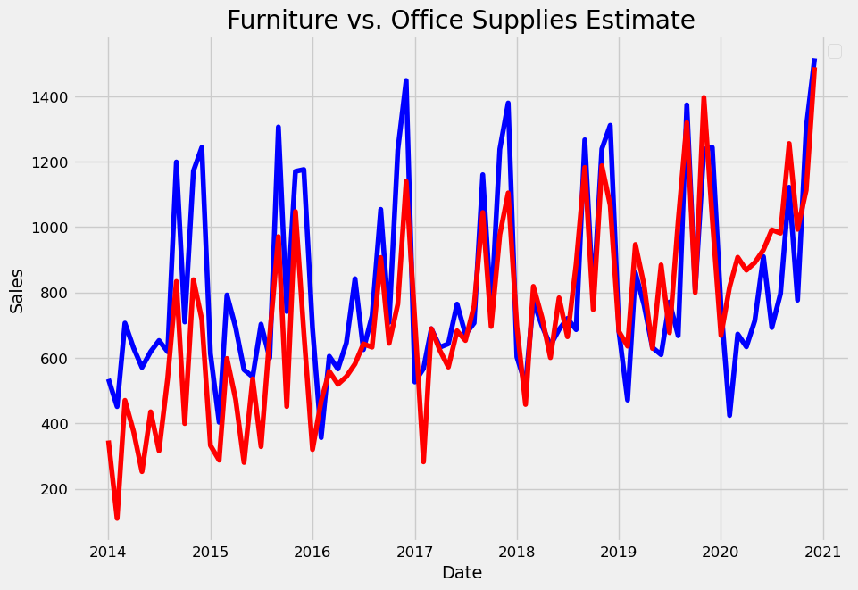

```python
plt.figure(figsize=(10, 7))
plt.plot(forecast['Date'], forecast['furniture_yhat'], 'b-')
plt.plot(forecast['Date'], forecast['office_yhat'], 'r-')
plt.legend(); plt.xlabel('Date'); plt.ylabel('Sales')
plt.title('Furniture vs. Office Supplies Estimate');
```

### Trends and Patterns

Now, we can use the Prophet Models to inspect different trends of these two categories in the data.

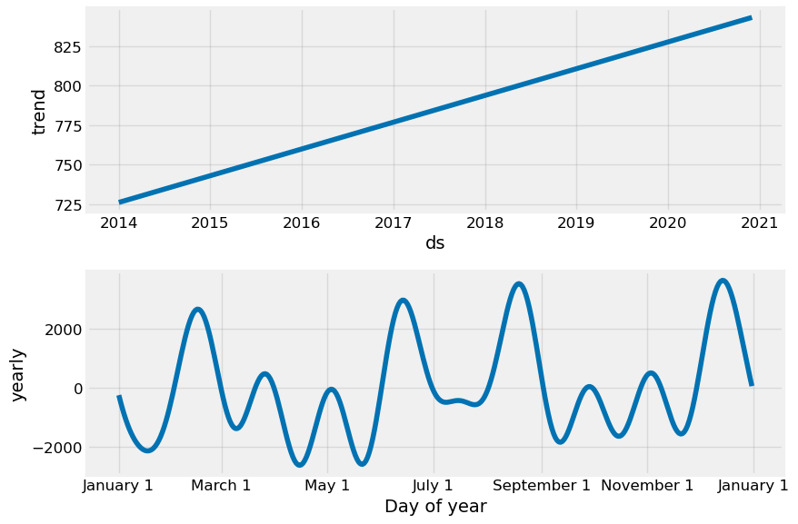

```python
furniture_model.plot_components(furniture_forecast);
```

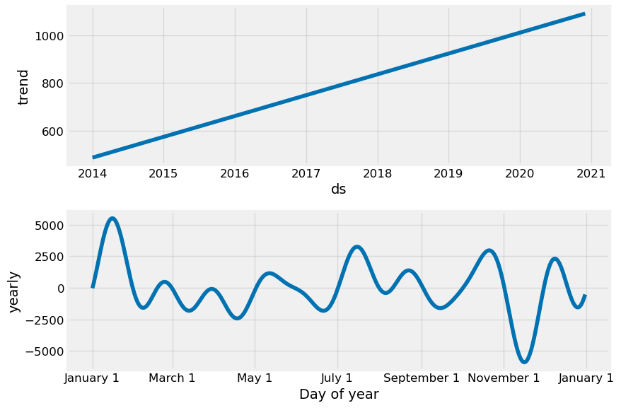

```python
office_model.plot_components(office_forecast);
```

There are many time-series analysis we can explore from now on, such as forecast with uncertainty bounds, change point and anomaly detection, forecast time-series with external data source. We have only scratched the surface here. Stay tuned for future works on time-series analysis.